# 成為初級資料分析師 | Python 機器學習

> 機器學習簡介

## 郭耀仁

> A computer program is said to learn from experience E with respect to some task T and some performance measure P, if its performance on T, as measured by P, improves with experience E.

> [Tom Mitchell](http://www.cs.cmu.edu/~tom/)

## 大綱

- 機器學習簡介
- 常見學習途徑

## 機器學習簡介

## 三個 Buzz-words

[figure not shown]

Source: [rapidminer](https://rapidminer.com/artificial-intelligence-machine-learning-deep-learning/)

## 機器學習是實踐人工智慧的手段，深度學習是機器學習中的一種方式

## 機器學習是透過程式讓電腦能夠從資料中學習的學科

說起來有點繞口令：Machine **learning** is the science of programming computers so they can **learn** from data.

## 精準地用一句話說明機器學習

> A computer program is said to learn from experience E with respect to some task T and some performance measure P, if its performance on T, as measured by P, improves with experience E.

> [Tom Mitchell](http://www.cs.cmu.edu/~tom/)

## 經驗：Experience, E

- 尋找已實現過的歷史資料，這些資料中具有輸入 $x$ 也具有輸出 $y$
- 通常稱呼為具有標籤的資料（Labeled data）

## 任務：Task, T

- 有些任務用固定的程式邏輯判斷、解決，例如判斷數字是否為質數
- 有些任務很難用固定的程式邏輯判斷、解決，例如數值預測、類別預測
  - 有特徵可循：其他機器學習演算法
  - 無特徵可循：深度學習演算法

## 判斷數字是否為質數

是否存在一個 $f$ 可以讓我們輸入 $x$ 就能夠回傳答案 $f(x)$？

- 輸入 $x$：正整數
- 輸出 $f(x)$：是否為質數

```python
arr = np.arange(1, 101)
print(arr)
```

```
[  1   2   3   4   5   6   7   8   9  10  11  12  13  14  15  16  17  18
  19  20  21  22  23  24  25  26  27  28  29  30  31  32  33  34  35  36
  37  38  39  40  41  42  43  44  45  46  47  48  49  50  51  52  53  54
  55  56  57  58  59  60  61  62  63  64  65  66  67  68  69  70  71  72
  73  74  75  76  77  78  79  80  81  82  83  84  85  86  87  88  89  90
  91  92  93  94  95  96  97  98  99 100]
```

## $f$ 能夠用固定的程式邏輯判斷、解決

```python
def is_prime(x):
    div_cnt = 0
    for i in range(1, x+1):
        if x % i == 0:
            div_cnt += 1
        if div_cnt > 2:
            break
    return int(div_cnt == 2)
f = np.vectorize(is_prime)
is_prime_arr = f(arr)
print(is_prime_arr)
```

```
[0 1 1 0 1 0 1 0 0 0 1 0 1 0 0 0 1 0 1 0 0 0 1 0 0 0 0 0 1 0 1 0 0 0 0 0 1
 0 0 0 1 0 1 0 0 0 1 0 0 0 0 0 1 0 0 0 0 0 1 0 1 0 0 0 0 0 1 0 0 0 1 0 1 0
 0 0 0 0 1 0 0 0 1 0 0 0 0 0 1 0 0 0 0 0 0 0 1 0 0 0]
```

```python
df = pd.DataFrame()
df['number'] = arr
df['is_prime'] = is_prime_arr
df
```

|  | number | is_prime |
| --- | --- | --- |
| 0 | 1 | 0 |
| 1 | 2 | 1 |
| 2 | 3 | 1 |
| 3 | 4 | 0 |
| 4 | 5 | 1 |
| ... | ... | ... |
| 95 | 96 | 0 |
| 96 | 97 | 1 |
| 97 | 98 | 0 |
| 98 | 99 | 0 |
| 99 | 100 | 0 |

100 rows × 2 columns

## 數值預測

是否存在一個 $f$ 可以讓我們輸入 $x$ 就能夠回傳答案 $f(x)$？

- 輸入 $x$：球員的身高
- 輸出 $f(x)$：球員的體重

```python
csv_url = "https://pyml.s3-ap-northeast-1.amazonaws.com/nba/players.csv"
players = pd.read_csv(csv_url)
heights = players['heightMeters'].values
print(heights)
```

```
[2.11 2.06 2.11 2.08 1.96 1.93 2.11 1.85 2.03 2.06 2.11 2.08 1.98 2.03
 2.01 1.9  2.03 1.8  2.11 1.98 2.11 1.98 2.13 1.78 2.03 1.98 1.96 2.03
 2.06 2.08 1.93 2.03 1.9  1.93 1.96 1.96 2.13 2.08 1.85 2.06 2.11 2.03
 2.08 1.85 1.98 2.03 2.18 1.9  2.03 1.96 2.06 1.98 1.85 1.9  2.08 1.96
 1.98 1.98 1.98 2.01 1.96 2.01 1.93 1.98 2.18 1.96 1.98 1.98 1.85 2.08
 1.98 1.98 1.93 2.01 2.06 2.03 1.96 2.03 2.08 1.98 1.85 1.98 2.06 1.96
 1.96 2.13 2.13 2.03 1.93 1.96 1.8  2.06 1.98 2.03 1.93 2.11 1.75 1.96
 2.01 2.06 2.11 1.85 1.96 1.85 2.01 2.01 1.98 1.98 1.88 1.9  1.93 2.08
 2.06 1.93 2.13 1.9  1.98 2.03 1.96 2.08 1.96 1.93 2.01 1.9  1.96 2.03
 1.98 1.9  2.08 1.98 1.9  2.08 1.8  1.93 2.13 1.98 2.06 1.93 1.96 2.26
 2.06 2.08 1.98 2.06 1.83 2.01 1.88 2.01 1.9  1.9  1.96 1.9  2.06 2.08
 2.08 1.85 1.85 2.11 2.03 2.03 2.06 2.11 1.96 2.16 1.83 2.03 1.9  1.85
 1.96 2.03 1.83 1.98 1.98 2.03 1.93 2.03 2.06 1.98 1.85 2.03 2.06 1.96
 1.96 2.01 1.78 2.01 1.93 1.98 2.03 2.01 1.96 2.13 2.03 2.11 2.01 2.06
 2.08 2.06 2.11 1.96 2.06 2.03 1.93 1.9  1.98 2.03 1.83 1.9  1.98 1.98
 2.08 2.03 2.06 1.93 1.98 2.08 2.03 2.01 2.01 2.01 2.13 1.98 2.06 2.01
 2.01 1.88 2.11 1.98 1.9  2.03 2.01 1.9  2.11 2.01 2.06 1.96 1.96 2.01
 2.01 2.03 2.01 1.96 1.98 2.13 2.11 1.83 1.98 2.11 1.9  2.06 2.13 2.08
 1.96 1.98 2.01 2.08 1.88 2.01 1.96 2.01 2.18 2.01 2.06 2.03 2.08 1.96
 1.93 1.98 2.01 2.03 2.08 1.93 1.96 1.96 2.13 2.01 2.13 1.98 1.88 1.96
 2.06 2.13 2.13 2.03 1.83 2.01 2.06 1.96 2.11 2.13 1.96 2.24 2.13 1.96
 1.96 1.88 1.96 1.8  1.96 1.93 2.01 1.9  1.85 2.08 2.01 2.13 1.93 2.01
 1.8  1.9  1.96 2.06 1.88 2.06 2.01 1.98 2.01 1.85 2.01 1.96 1.85 1.9
 1.96 1.9  1.88 1.9  1.9  2.01 2.03 1.88 2.03 2.03 1.9  1.9  1.93 1.93
 2.06 2.08 2.01 1.96 2.01 1.83 1.85 2.01 2.11 2.08 1.93 1.93 1.88 2.13
 1.93 2.06 1.98 2.08 1.9  1.93 2.03 1.93 2.11 1.96 2.01 2.01 2.08 2.03
 1.98 2.18 2.03 1.85 1.9  1.9  2.08 1.96 2.11 2.16 1.98 2.13 1.93 2.11
 1.93 2.08 2.03 2.08 2.21 2.08 1.9  2.01 1.88 2.03 1.93 2.03 1.9  2.06
 2.01 1.96 1.9  2.01 2.01 1.93 2.13 1.98 2.03 1.85 1.88 1.98 1.85 1.9
 1.93 2.11 2.08 2.01 2.08 2.01 1.96 1.85 2.01 1.98 1.85 1.93 1.96 2.06
 2.03 2.08 1.96 1.9  2.08 1.9  1.83 1.9  1.88 1.98 2.06 2.03 1.96 1.93
 2.06 2.03 1.9  1.96 2.03 1.9  1.93 1.98 2.06 1.96 1.98 2.11 1.96 1.93
 1.96 1.9  1.98 2.11 2.11 1.93 2.06 1.85 1.9  2.08 2.11 2.06 2.11 1.9
 1.83 1.96 1.93 1.9  2.03 2.01 2.03 1.78 1.98 1.9  1.9  1.93 1.93 2.13
 2.01 1.98 2.06 1.98 1.85 2.03 1.88 2.03 1.98 2.08 1.98 1.98 2.08 2.03
 1.96 1.83 2.03 1.85 2.13 2.08 2.13]
```

## 我們很難用固定的程式邏輯判斷出 $f$ 為何，但假設 $f$ 存在，使用機器學習找出一個可能跟 $f$ 長得很像的 $h$

- 使用前 70% 球員的身高跟體重讓電腦程式猜 $h$ 為何
- 將後 30% 球員的身高輸入 $h$ 看預測結果為何

```python
from sklearn.linear_model import LinearRegression

weights = players['weightKilograms'].values
train_index = round(0.7*(heights.size))
X_train = heights[:train_index].reshape(-1, 1)
y_train = weights[:train_index]
X_valid = heights[train_index:].reshape(-1, 1)
y_valid = weights[train_index:]
lr = LinearRegression()
h = lr.fit(X_train, y_train)
y_hat = h.predict(X_valid)
```

```python
df = pd.DataFrame()
df['height'] = X_valid.ravel()
df['weight_true'] = y_valid
df['weight_predict'] = y_hat
df
```

|  | height | weight_true | weight_predict |
| --- | --- | --- | --- |
| 0 | 1.88 | 86.2 | 87.620260 |
| 1 | 2.13 | 131.5 | 112.126928 |
| 2 | 1.93 | 102.5 | 92.521594 |
| 3 | 2.06 | 113.4 | 105.265061 |
| 4 | 1.98 | 108.9 | 97.422927 |
| ... | ... | ... | ... |
| 144 | 2.03 | 106.6 | 102.324261 |
| 145 | 1.85 | 81.6 | 84.679460 |
| 146 | 2.13 | 108.9 | 112.126928 |
| 147 | 2.08 | 120.7 | 107.225594 |
| 148 | 2.13 | 108.9 | 112.126928 |

149 rows × 3 columns

## 類別預測

是否存在一個 $f$ 可以讓我們輸入 $x$ 就能夠回傳答案 $f(x)$？

- 輸入 $x$：球員的身高
- 輸出 $f(x)$：球員是否屬於前場位置（前鋒或者中鋒）？

## 我們很難用固定的程式邏輯判斷出 $f$ 為何，但假設 $f$ 存在，使用機器學習找出一個可能跟 $f$ 長得很像的 $h$

- 使用前 70% 球員的身高跟是否屬於前場位置讓電腦程式猜 $h$ 為何
- 將後 30% 球員的身高輸入 $h$ 看預測結果為何

```python
print(players['pos'].unique())
is_front_court = players['pos'].apply(lambda x: 1 if x in ['C', 'C-F', 'F-C', 'F', 'F-G'] else 0).values
print(is_front_court)
```

```
['C' 'C-F' 'F-C' 'G' 'F' 'F-G' 'G-F']
[1 1 1 1 0 0 1 0 1 1 1 1 1 1 1 0 1 0 1 0 1 0 1 0 1 1 0 1 0 1 0 1 0 0 0 0 1
 1 0 1 1 1 1 0 0 1 1 0 0 0 1 1 0 0 1 1 1 1 1 1 0 0 0 0 1 0 0 0 0 1 0 0 0 1
 1 1 0 1 1 1 0 0 1 0 0 1 1 1 0 1 0 1 1 1 0 1 0 0 0 1 1 0 0 0 1 1 1 0 0 0 0
 1 1 0 1 0 0 1 0 1 0 0 1 0 0 1 0 0 1 1 0 1 0 0 1 1 1 0 0 1 1 1 0 1 0 1 0 0
 0 0 0 0 1 1 1 0 0 1 1 1 1 1 0 1 0 1 0 0 0 1 0 0 1 1 0 1 1 0 0 1 1 0 0 1 0
 1 0 0 1 0 0 1 1 1 1 1 1 1 1 0 1 1 0 0 1 1 0 0 1 1 1 0 1 0 1 1 1 0 1 1 1 0
 1 1 1 0 1 1 0 0 1 0 1 0 1 0 0 1 1 1 1 1 1 1 1 0 1 1 0 1 1 1 0 1 1 1 0 1 0
 0 1 0 1 1 1 0 0 0 1 1 1 0 0 0 1 1 1 0 0 1 1 1 1 1 0 0 1 0 1 1 0 1 1 1 1 0
 1 0 0 0 0 0 0 1 1 1 0 1 0 0 0 1 0 1 1 1 0 0 1 0 0 0 0 0 0 0 0 1 1 0 1 1 0
 0 0 0 0 1 0 1 1 0 0 1 1 1 0 0 0 1 1 1 1 1 1 0 1 0 1 0 1 1 1 1 1 1 1 0 0 0
 1 0 1 1 0 1 0 1 0 1 1 1 1 1 0 1 0 1 0 1 0 1 0 0 0 0 1 0 1 1 1 0 0 0 0 0 0
 1 1 1 1 0 0 0 1 1 0 0 0 1 1 0 0 0 1 0 0 0 0 0 1 1 0 0 1 1 0 0 1 0 0 0 1 0
 1 1 0 0 1 0 0 1 1 0 1 0 0 1 1 1 1 0 0 0 0 0 1 1 0 0 0 0 0 0 0 1 1 1 1 0 0
 1 0 1 1 1 0 1 1 1 0 0 1 0 1 1 1]
```

```python
from sklearn.linear_model import LogisticRegression

train_index = round(0.7*(heights.size))
X_train = heights[:train_index].reshape(-1, 1)
y_train = is_front_court[:train_index]
X_valid = heights[train_index:].reshape(-1, 1)
y_valid = is_front_court[train_index:]
logit = LogisticRegression()
h = logit.fit(X_train, y_train)
y_hat = h.predict(X_valid)
```

```python
df = pd.DataFrame()
df['height'] = X_valid.ravel()
df['is_front_court_true'] = y_valid
df['is_front_court_predict'] = y_hat
df
```

|  | height | is_front_court_true | is_front_court_predict |
| --- | --- | --- | --- |
| 0 | 1.88 | 0 | 0 |
| 1 | 2.13 | 1 | 1 |
| 2 | 1.93 | 1 | 0 |
| 3 | 2.06 | 1 | 1 |
| 4 | 1.98 | 1 | 1 |
| ... | ... | ... | ... |
| 144 | 2.03 | 1 | 1 |
| 145 | 1.85 | 0 | 0 |
| 146 | 2.13 | 1 | 1 |
| 147 | 2.08 | 1 | 1 |
| 148 | 2.13 | 1 | 1 |

149 rows × 3 columns

## 勇者鬥惡龍：擊敗龍王的任務

[figure not shown]

Source: https://dragonquest.square-enix-games.com

## 機器學習：尋找 $h$ 的任務

於可及範圍的 $H$ 中挑選一個與 $f$ 最相似的 $h_i$

$$y = f(x)$$$$\boldsymbol{H} = \{h_1,h_2,\dotsc,h_n\}$$$$\hat{y_i} = h_i(x)$$

## 何謂可及範圍的 $H$？

- 以類別預測為例，除了使用 Scikit-Learn 已經寫好的分類器 `LogisticRegression`（做為 $h_1$）
- 亦可以自己定義一個分類器做為 $h_2$
- 亦可以丟銅板決定做為 $h_3$

```python
# h1
logit = LogisticRegression()
h1 = logit.fit(X_train, y_train)
y_hat_h1 = h1.predict(X_valid)
```

## 自己定義一個分類器做為 $h_2$

```python
# h2
class my_classifier:
    def predict(self, x):
        self.x = x
        return np.where(self.x >= 2.03, 1, 0).ravel()

h2 = my_classifier()
y_hat_h2 = h2.predict(X_valid)
```

## 丟銅板決定做為 $h_3$

```python
# h3
class coin_classifier:
    def predict(self, x):
        self.x = x
        arr_len = self.x.size
        return np.random.randint(0, 2, size=arr_len)

h3 = coin_classifier()
y_hat_h3 = h3.predict(X_valid)
```

```python
df = pd.DataFrame()
df['height'] = X_valid.ravel()
df['is_front_court_true'] = y_valid
df['is_front_court_h1'] = y_hat_h1
df['is_front_court_h2'] = y_hat_h2
df['is_front_court_h3'] = y_hat_h3
df
```

|  | height | is_front_court_true | is_front_court_h1 | is_front_court_h2 | is_front_court_h3 |
| --- | --- | --- | --- | --- | --- |
| 0 | 1.88 | 0 | 0 | 0 | 1 |
| 1 | 2.13 | 1 | 1 | 1 | 0 |
| 2 | 1.93 | 1 | 0 | 0 | 1 |
| 3 | 2.06 | 1 | 1 | 1 | 1 |
| 4 | 1.98 | 1 | 1 | 0 | 0 |
| ... | ... | ... | ... | ... | ... |
| 144 | 2.03 | 1 | 1 | 1 | 1 |
| 145 | 1.85 | 0 | 0 | 0 | 0 |
| 146 | 2.13 | 1 | 1 | 1 | 0 |
| 147 | 2.08 | 1 | 1 | 1 | 1 |
| 148 | 2.13 | 1 | 1 | 1 | 1 |

149 rows × 5 columns

## 該如何判斷可及範圍中的哪個 $h_i$ 與 $f$ 最相似呢？

- 比對哪一個 $h_i$ 所預測的 $\hat{y_i}$ 與 $y$ 最相似
- 進而推論哪個 $h_i$ 與 $f$ 最相似

## 評估：Performance, P

利用量化的指標來衡量哪個 $h_i$ 與 $f$ 最相似

```python
# 相同的筆數愈多，代表相似程度愈高
print((y_valid == y_hat_h1).sum())
print((y_valid == y_hat_h2).sum())
print((y_valid == y_hat_h3).sum())
```

```
133
128
75
```

## 何謂無特徵可循的情況呢？

- 在前述的例子中，**身高**是我們所找的特徵
- 但許多任務是無特徵可依循的，像是圖片辨識、文字翻譯或者雜訊去除等
- 這時可以使用深度學習來應對

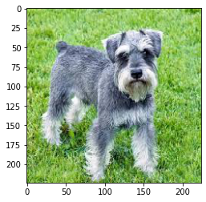

```python
from tensorflow.keras.preprocessing.image import load_img
import matplotlib.pyplot as plt

#!wget --output-document=schnauzer.jpeg https://i.imgur.com/LWBF92t.jpg
schnauzer = load_img("schnauzer.jpeg", target_size=(224, 224))
fig, ax = plt.subplots()
ax.imshow(schnauzer)
plt.show()
```

```python
from tensorflow.keras.preprocessing import image

x = image.img_to_array(schnauzer)
print(x.shape)
print(x)
```

```
(224, 224, 3)
[[[161. 216. 115.]
  [159. 211. 111.]
  [161. 212. 109.]
  ...
  [128. 172.  49.]
  [146. 190.  67.]
  [167. 211.  87.]]

 [[162. 217. 113.]
  [160. 213. 109.]
  [167. 218. 113.]
  ...
  [127. 172.  53.]
  [142. 187.  68.]
  [159. 205.  83.]]

 [[162. 216. 105.]
  [155. 209.  98.]
  [167. 220. 106.]
  ...
  [111. 162.  44.]
  [124. 175.  57.]
  [138. 189.  70.]]

 ...

 [[102. 159.  54.]
  [ 86. 141.  37.]
  [ 63. 118.  14.]
  ...
  [134. 193.  85.]
  [136. 194.  92.]
  [132. 188.  89.]]

 [[ 80. 136.  37.]
  [ 82. 137.  36.]
  [ 97. 149.  49.]
  ...
  [123. 182.  74.]
  [134. 191.  88.]
  [126. 182.  81.]]

 [[ 70. 124.  30.]
  [ 67. 121.  25.]
  [109. 160.  65.]
  ...
  [124. 182.  72.]
  [140. 197.  92.]
  [129. 186.  83.]]]
```

```python
from tensorflow.keras.applications.resnet50 import ResNet50
from tensorflow.keras.applications.resnet50 import preprocess_input, decode_predictions

model = ResNet50(weights='imagenet')
x = np.expand_dims(x, axis=0)
x = preprocess_input(x)
preds = model.predict(x)
for i, j, k in decode_predictions(preds, top=5)[0]:
    print("這張圖片是 {} 的機率為 {:.2f}%".format(j, k*100))
```

```
這張圖片是 standard_schnauzer 的機率為 87.24%
這張圖片是 miniature_schnauzer 的機率為 12.38%
這張圖片是 giant_schnauzer 的機率為 0.37%
這張圖片是 Bouvier_des_Flandres 的機率為 0.00%
這張圖片是 wire-haired_fox_terrier 的機率為 0.00%
```

## 機器學習是否適合用來解決所有的問題？

試著用機器學習的方式解決固定的程式邏輯可以完成的事情，像是判斷數字是否為質數？

```python
x = np.arange(1, 101)
is_even_arr = np.where(x % 2 == 0, 1, 0)
is_prime_arr = f(x)
df = pd.DataFrame()
df['number'] = x
df['is_even'] = is_even_arr
df['is_prime'] = is_prime_arr
df
```

|  | number | is_even | is_prime |
| --- | --- | --- | --- |
| 0 | 1 | 0 | 0 |
| 1 | 2 | 1 | 1 |
| 2 | 3 | 0 | 1 |
| 3 | 4 | 1 | 0 |
| 4 | 5 | 0 | 1 |
| ... | ... | ... | ... |
| 95 | 96 | 1 | 0 |
| 96 | 97 | 0 | 1 |
| 97 | 98 | 1 | 0 |
| 98 | 99 | 0 | 0 |
| 99 | 100 | 1 | 0 |

100 rows × 3 columns

```python
from sklearn.ensemble import RandomForestClassifier

X = df[['number', 'is_even']].values
y = df['is_prime'].values
rf = RandomForestClassifier()
h = rf.fit(X, y)
```

```python
x = np.arange(101, 151)
y_true = f(x)
is_even_arr = np.where(x % 2 == 0, 1, 0)
X_test = np.concatenate([x.reshape(-1, 1), is_even_arr.reshape(-1, 1)], axis=1)
y_hat = h.predict(X_test)
df = pd.DataFrame()
df['number'] = x
df['is_even'] = is_even_arr
df['y_true'] = y_true
df['y_hat'] = y_hat
```

```python
print((y_true == y_hat).sum())
df.head()
```

```
40
```

|  | number | is_even | y_true | y_hat |
| --- | --- | --- | --- | --- |
| 0 | 101 | 0 | 1 | 0 |
| 1 | 102 | 1 | 0 | 0 |
| 2 | 103 | 0 | 1 | 0 |
| 3 | 104 | 1 | 0 | 0 |
| 4 | 105 | 0 | 0 | 0 |

## 機器學習的全景

- 監督式學習（Supervised Learning）
- 半監督式學習（Semi-supervised Learning）
- 遷移學習（Transfer Learning）
- 非監督式學習（Unsupervised Learning）
- 結構式學習（Structured Learning）
- 強化式學習（Reinforcement Learning）
- 未知的

## 端到端（End-to-end）的資料科學專案示意圖

[figure not shown]

Source: [R for Data Science](https://r4ds.had.co.nz/)

## 端到端（End-to-end）

- 獲取資料（Import）
- 掌握資料（Tidy、Transform）
- 探索資料（Visualise）
- 機器學習（Model）
- 溝通資料（Communicate）

## 如何利用 Program 完成端到端的資料科學專案

- Import: `requests`, `pandas`
- Tidy/Transform: `numpy`, `pandas`, `sklearn`
- Visualise: `matplotlib`
- Model: `sklearn`, `tensorflow`
- Commnunicate: `plotly`, `dash`

## 常見學習途徑

## 千里之行，始於足下

- 從理論著手
- 從工具（Scikit-Learn、TensorFlow、PyTorch...）著手
- 從練習著手

## 從理論著手

- [Andrew Ng: Machine Learning](https://www.coursera.org/learn/machine-learning)
- [林軒田：機器學習基石](https://www.coursera.org/learn/ntumlone-mathematicalfoundations/)
- [李宏毅：機器學習](https://www.youtube.com/playlist?list=PLJV_el3uVTsPy9oCRY30oBPNLCo89yu49)
- [Deep Learning](https://www.deeplearningbook.org/)
- [Introduction to Statistical Learning](http://www-bcf.usc.edu/~gareth/ISL/)
- [The Elements of Statistical Learning](https://web.stanford.edu/~hastie/ElemStatLearn/)

## 從工具著手

- [Scikit-Learn](https://scikit-learn.org/stable/)
- [Google Machine Learning Crash Course](https://developers.google.com/machine-learning/crash-course/ml-intro)
- [fast.ai](https://www.fast.ai/)
- [Introduction to TensorFlow for Artificial Intelligence, Machine Learning, and Deep Learning](https://www.coursera.org/learn/introduction-tensorflow)

## 從練習著手

- [Kaggle.com](https://www.kaggle.com/)
- [DataCamp](https://www.datacamp.com?tap_a=5644-dce66f&tap_s=194899-1fb421&utm_medium=affiliate&utm_source=tonykuo)

## 這堂課嘗試從這三個面向找到一個 Balanced 的學習途徑